# Tuber_analysis_2

Max Miao

June 21, 2019

Found some extra Tubers. Need to reanalyze:

## Re-examining datasets and recalculating reletivized values:

```r
library(tidyverse)
```

```r
meta_tuber_data <- read.csv("tuber_analysis_2.csv", header = T)

#extracting rows to calculate sterile averages for each variety
sterile_avg = meta_tuber_data %>%
  filter(soil == "Sterile", tuber3 != "#NA") %>%
  group_by(variety2,Clade,Nutrient) %>%
  summarize(mean(tuber3),n = n()) %>%
  rename(sterile_avg = "mean(tuber3)")


#Now we want to calculate relativized values shoot/avg for each variety
meta_tuber_data <- merge(meta_tuber_data,sterile_avg, by=c("variety2","Nutrient"))

#relativize our values:
new_meta_data <- transform(meta_tuber_data, rel_biomass = tuber3/sterile_avg)
write.csv(new_meta_data,"rel_tuber_analysis.csv")
```

So, we have a math issue. We can’t divide by zero. So we’ll maybe do a weighted average for each clade. Also we will then test to see if tubermass variation is greater between clades than within. We hope to see that tubermass variation is greater between clades and not within.

```r
#Calculate Weighted Average
meta_tuber_data <- read.csv("tuber_analysis_2.csv", header = T)
wgt_average = meta_tuber_data  %>%
  filter(soil == "Sterile") %>%
  group_by(agerank2,Nutrient) %>%
  summarise(tuber_mean=mean(tuber3),n=n()) %>%
  summarise(wgt_avg = weighted.mean(tuber_mean,n),obs=sum(n))

#Merge Data set to "new_meta_data"
meta_tuber_data <- merge(meta_tuber_data,wgt_average, by=c("agerank2"))

#WOW now we have our weighted averages based on clade and nutrient regime. We will now proceed to relativizing based on weighted average just calculated.

new_meta_data2 <- transform(meta_tuber_data, rel_biomass2 = tuber3/wgt_avg)
write.csv(new_meta_data2, "rel_tuber_analysis.csv")

#to Verify that this method is sound perform a statistical test:
library(lme4)
library(lmerTest)
a <- lmer(rel_biomass2 ~ Clade*Nutrient + variety2 + (1|Clade:variety2), data = new_meta_data2)
```

```
## fixed-effect model matrix is rank deficient so dropping 3 columns / coefficients
```

```r
summary(a)
```

```
## Linear mixed model fit by REML. t-tests use Satterthwaite's method [
## lmerModLmerTest]
## Formula: rel_biomass2 ~ Clade * Nutrient + variety2 + (1 | Clade:variety2)
##    Data: new_meta_data2
##
## REML criterion at convergence: 923.1
##
## Scaled residuals:
##     Min      1Q  Median      3Q     Max
## -2.0813 -0.4782 -0.1242  0.3755  7.6202
##
## Random effects:
##  Groups         Name        Variance Std.Dev.
##  Clade:variety2 (Intercept) 0.2974   0.5454
##  Residual                   0.8682   0.9318
## Number of obs: 340, groups:  Clade:variety2, 17
##
## Fixed effects:
##                          Estimate Std. Error         df t value Pr(>|t|)
## (Intercept)             7.473e-01  5.851e-01  1.977e-09   1.277 1.000000
## Cladebert              -3.468e-01  8.415e-01  2.114e-09  -0.412 1.000000
## Cladechil               6.220e-01  8.325e-01  2.025e-09   0.747 1.000000
## Cladeelite              7.005e-01  8.289e-01  1.991e-09   0.845 1.000000
## NutrientLow             1.371e+00  1.871e-01  3.190e+02   7.331 1.90e-12
## variety2Cor C 135      -7.869e-01  8.301e-01  2.002e-09  -0.948 1.000000
## variety2Cor C56        -3.190e-01  8.270e-01  1.973e-09  -0.386 1.000000
## variety2Cor C95        -8.603e-01  8.226e-01  1.931e-09  -1.046 1.000000
## variety2EBS 1797        3.302e-01  8.189e-01  1.896e-09   0.403 1.000000
## variety2Garnet         -3.553e-01  8.246e-01  1.950e-09  -0.431 1.000000
## variety2HAO 58         -2.308e-01  8.314e-01  2.015e-09  -0.278 1.000000
## variety2HAO 76          1.369e+00  8.314e-01  2.015e-09   1.646 1.000000
## variety2Huagalina      -3.578e-01  8.212e-01  1.918e-09  -0.436 1.000000
## variety2Norkodah       -1.496e-01  8.253e-01  1.956e-09  -0.181 1.000000
## variety2Ranger         -5.172e-03  8.223e-01  1.928e-09  -0.006 1.000000
## variety2Snowden        -3.013e-01  8.198e-01  1.905e-09  -0.368 1.000000
## variety2WAC 5          -4.544e-01  8.259e-01  1.962e-09  -0.550 1.000000
## variety2WAC 663        -6.911e-01  8.260e-01  1.963e-09  -0.837 1.000000
## Cladebert:NutrientLow  -1.321e+00  3.164e-01  3.190e+02  -4.176 3.83e-05
## Cladechil:NutrientLow  -9.602e-01  2.623e-01  3.190e+02  -3.661 0.000295
## Cladeelite:NutrientLow -1.988e+00  2.776e-01  3.190e+02  -7.162 5.54e-12
```

[output cut: 9 more lines]

```
## variety2EBS 1797
## variety2Garnet
## variety2HAO 58
## variety2HAO 76
## variety2Huagalina
## variety2Norkodah
## variety2Ranger
## variety2Snowden
## variety2WAC 5
## variety2WAC 663
## Cladebert:NutrientLow  ***
## Cladechil:NutrientLow  ***
## Cladeelite:NutrientLow ***
## ---
## Signif. codes:  0 '***' 0.001 '**' 0.01 '*' 0.05 '.' 0.1 ' ' 1
```

```
##
## Correlation matrix not shown by default, as p = 21 > 12.
## Use print(x, correlation=TRUE)  or
##     vcov(x)        if you need it
```

```
## fit warnings:
## fixed-effect model matrix is rank deficient so dropping 3 columns / coefficients
```

```r
anova(a)
```

|  | Sum Sq | Mean Sq | NumDF | DenDF | F value | Pr(>F) |
| --- | --- | --- | --- | --- | --- | --- |
| Clade | 1.983394 | 0.6611314 | 3 | 1.943491e-09 | 0.7614648 | 1.000000e+00 |
| Nutrient | 7.289915 | 7.2899151 | 1 | 3.190000e+02 | 8.3962331 | 4.020161e-03 |
| variety2 | 6.855119 | 0.5273168 | 13 | 1.965340e-09 | 0.6073424 | 1.000000e+00 |
| Clade:Nutrient | 46.363454 | 15.4544847 | 3 | 3.190000e+02 | 17.7998581 | 1.046255e-10 |

```r
b <- lmer(tuber3 ~ Clade*Nutrient + variety2 + (1|Clade:variety2), data = new_meta_data2)
```

```
## fixed-effect model matrix is rank deficient so dropping 3 columns / coefficients
```

```r
summary(b)
```

```
## Linear mixed model fit by REML. t-tests use Satterthwaite's method [
## lmerModLmerTest]
## Formula: tuber3 ~ Clade * Nutrient + variety2 + (1 | Clade:variety2)
##    Data: new_meta_data2
##
## REML criterion at convergence: 3207.3
##
## Scaled residuals:
##     Min      1Q  Median      3Q     Max
## -3.5544 -0.4677 -0.1324  0.4737  3.2082
##
## Random effects:
##  Groups         Name        Variance Std.Dev.
##  Clade:variety2 (Intercept)  935.6   30.59
##  Residual                   1118.0   33.44
## Number of obs: 340, groups:  Clade:variety2, 17
##
## Fixed effects:
##                        Estimate Std. Error       df t value Pr(>|t|)
## (Intercept)             11.2902    31.5188 319.0000   0.358  0.72043
## Cladebert                0.9004    44.9112 319.0000   0.020  0.98402
## Cladechil               53.3842    44.6949 319.0000   1.194  0.23320
## Cladeelite             121.2464    44.6097 319.0000   2.718  0.00693 **
## NutrientLow             20.7187     6.7132 319.0000   3.086  0.00220 **
## variety2Cor C 135      -36.8756    44.6365 319.0000  -0.826  0.40935
## variety2Cor C56        -14.9565    44.5640 319.0000  -0.336  0.73738
## variety2Cor C95        -40.3657    44.4593 319.0000  -0.908  0.36460
## variety2EBS 1797         4.9887    44.3697 319.0000   0.112  0.91055
## variety2Garnet          12.8439    44.5069 319.0000   0.289  0.77309
## variety2HAO 58          -7.0244    44.6699 319.0000  -0.157  0.87515
## variety2HAO 76          41.6611    44.6699 319.0000   0.933  0.35171
## variety2Huagalina       -5.4061    44.4259 319.0000  -0.122  0.90322
## variety2Norkodah       -13.6911    44.5221 319.0000  -0.308  0.75865
## variety2Ranger          -0.4735    44.4518 319.0000  -0.011  0.99151
## variety2Snowden        -27.5806    44.3917 319.0000  -0.621  0.53485
## variety2WAC 5           -6.8648    44.5372 319.0000  -0.154  0.87760
## variety2WAC 663        -10.4412    44.5407 319.0000  -0.234  0.81481
## Cladebert:NutrientLow  -19.1989    11.3541 319.0000  -1.691  0.09183 .
## Cladechil:NutrientLow   -2.2335     9.4128 319.0000  -0.237  0.81259
## Cladeelite:NutrientLow -77.1917     9.9624 319.0000  -7.748 1.25e-13 ***
## ---
## Signif. codes:  0 '***' 0.001 '**' 0.01 '*' 0.05 '.' 0.1 ' ' 1
```

```
##
## Correlation matrix not shown by default, as p = 21 > 12.
## Use print(x, correlation=TRUE)  or
##     vcov(x)        if you need it
```

```
## fit warnings:
## fixed-effect model matrix is rank deficient so dropping 3 columns / coefficients
```

```r
anova(b)
```

|  | Sum Sq | Mean Sq | NumDF | DenDF | F value | Pr(>F) |
| --- | --- | --- | --- | --- | --- | --- |
| Clade | 6396.578 | 2132.1927 | 3 | 319 | 1.9071604 | 1.282803e-01 |
| Nutrient | 1223.627 | 1223.6274 | 1 | 319 | 1.0944854 | 2.962716e-01 |
| variety2 | 4694.790 | 361.1377 | 13 | 319 | 0.3230231 | 9.883149e-01 |
| Clade:Nutrient | 84970.554 | 28323.5180 | 3 | 319 | 25.3342446 | 9.987074e-15 |

We now can say that weighted average method was alright! Don’t have to worry about genotype effect because its not statistically significant. There’s a statistical significant difference in how the plant are reacting to fertilizer treatment.

# Model fitting

```r
rel_tuber <- lmer(rel_biomass2 ~ Nutrient*agerank2*soil + (1|Variety), data = subset(new_meta_data2, agerank2 != 1, soil != "Sterile"))
summary(rel_tuber)
```

```
## Linear mixed model fit by REML. t-tests use Satterthwaite's method [
## lmerModLmerTest]
## Formula: rel_biomass2 ~ Nutrient * agerank2 * soil + (1 | Variety)
##    Data: subset(new_meta_data2, agerank2 != 1, soil != "Sterile")
##
## REML criterion at convergence: 800.1
##
## Scaled residuals:
##     Min      1Q  Median      3Q     Max
## -1.9274 -0.6058 -0.0806  0.4113  7.6674
##
## Random effects:
##  Groups   Name        Variance Std.Dev.
##  Variety  (Intercept) 0.02426  0.1558
##  Residual             0.88935  0.9431
## Number of obs: 286, groups:  Variety, 112
##
## Fixed effects:
##                                    Estimate Std. Error         df t value
## (Intercept)                        0.157995   0.436185 186.854879   0.362
## NutrientLow                        3.021948   0.583785 261.959907   5.176
## agerank2                           0.232345   0.128811 186.344449   1.804
## soilSterile                       -0.650077   0.590701 263.094076  -1.101
## soilVirgin                         0.102073   0.571280 262.114048   0.179
## NutrientLow:agerank2              -0.742833   0.169574 261.620514  -4.381
## NutrientLow:soilSterile           -0.280105   0.814633 263.713706  -0.344
## NutrientLow:soilVirgin            -0.847751   0.790875 262.262138  -1.072
## agerank2:soilSterile               0.128036   0.169578 260.898051   0.755
## agerank2:soilVirgin                0.008388   0.164161 261.478138   0.051
## NutrientLow:agerank2:soilSterile   0.081597   0.232223 261.219496   0.351
## NutrientLow:agerank2:soilVirgin    0.154948   0.226604 261.108239   0.684
##                                  Pr(>|t|)
## (Intercept)                        0.7176
## NutrientLow                      4.51e-07 ***
## agerank2                           0.0729 .
## soilSterile                        0.2721
## soilVirgin                         0.8583
## NutrientLow:agerank2             1.71e-05 ***
## NutrientLow:soilSterile            0.7312
## NutrientLow:soilVirgin             0.2847
```

[output cut: 17 more lines]

```
## agrnk2:slVr  0.686 -0.512 -0.733 -0.506 -0.936  0.557  0.368  0.677  0.556
## NtrntLw:2:S -0.486  0.684  0.519  0.686  0.371 -0.730 -0.938 -0.505 -0.731
## NtrntLw:2:V -0.497  0.701  0.531  0.366  0.679 -0.749 -0.503 -0.936 -0.403
##             agr2:V NL:2:S
## NutrientLow
## agerank2
## soilSterile
## soilVirgin
## NtrntLw:gr2
## NtrntLw:slS
## NtrntLw:slV
## agrnk2:slSt
## agrnk2:slVr
## NtrntLw:2:S -0.407
## NtrntLw:2:V -0.725  0.547
```

```r
anova(rel_tuber)
```

|  | Sum Sq | Mean Sq | NumDF | DenDF | F value | Pr(>F) |
| --- | --- | --- | --- | --- | --- | --- |
| Nutrient | 59.2013436 | 59.2013436 | 1 | 261.54873 | 66.5670107 | 1.428722e-14 |
| agerank2 | 0.8107198 | 0.8107198 | 1 | 13.83858 | 0.9115873 | 3.560754e-01 |
| soil | 3.4108262 | 1.7054131 | 2 | 261.44663 | 1.9175959 | 1.490211e-01 |
| Nutrient:agerank2 | 46.1714427 | 46.1714427 | 1 | 259.65545 | 51.9159656 | 6.285312e-12 |
| Nutrient:soil | 1.0840419 | 0.5420210 | 2 | 262.64998 | 0.6094577 | 5.444126e-01 |
| agerank2:soil | 1.8861725 | 0.9430863 | 2 | 259.26192 | 1.0604225 | 3.478066e-01 |
| Nutrient:agerank2:soil | 0.4164752 | 0.2082376 | 2 | 260.48716 | 0.2341459 | 7.914127e-01 |

```r
new_data <- subset(new_meta_data2, agerank2 != 1, soil != "Sterile")
new_data <- subset(new_data, Nutrient == "Low")
rel_tuber <- lmer(rel_biomass2 ~ agerank2*soil + (1|Variety), data = new_data)
summary(rel_tuber)
```

```
## Linear mixed model fit by REML. t-tests use Satterthwaite's method [
## lmerModLmerTest]
## Formula: rel_biomass2 ~ agerank2 * soil + (1 | Variety)
##    Data: new_data
##
## REML criterion at convergence: 391.9
##
## Scaled residuals:
##     Min      1Q  Median      3Q     Max
## -1.9843 -0.4413 -0.0029  0.4508  4.1747
##
## Random effects:
##  Groups   Name        Variance Std.Dev.
##  Variety  (Intercept) 0.0000   0.0000
##  Residual             0.7778   0.8819
## Number of obs: 148, groups:  Variety, 61
##
## Fixed effects:
##                      Estimate Std. Error       df t value Pr(>|t|)
## (Intercept)            3.2287     0.3774 142.0000   8.556 1.71e-14 ***
## agerank2              -0.5220     0.1075 142.0000  -4.853 3.16e-06 ***
## soilSterile           -0.9443     0.5228 142.0000  -1.806    0.073 .
## soilVirgin            -0.7737     0.5102 142.0000  -1.517    0.132
## agerank2:soilSterile   0.2133     0.1480 142.0000   1.441    0.152
## agerank2:soilVirgin    0.1695     0.1458 142.0000   1.163    0.247
## ---
## Signif. codes:  0 '***' 0.001 '**' 0.01 '*' 0.05 '.' 0.1 ' ' 1
##
## Correlation of Fixed Effects:
##             (Intr) agrnk2 slStrl slVrgn agr2:S
## agerank2    -0.937
## soilSterile -0.722  0.677
## soilVirgin  -0.740  0.693  0.534
## agrnk2:slSt  0.681 -0.727 -0.938 -0.504
## agrnk2:slVr  0.692 -0.738 -0.499 -0.937  0.536
```

```r
anova(rel_tuber)
```

|  | Sum Sq | Mean Sq | NumDF | DenDF | F value | Pr(>F) |
| --- | --- | --- | --- | --- | --- | --- |
| agerank2 | 34.465442 | 34.4654416 | 1 | 142 | 44.312131 | 5.663143e-10 |
| soil | 2.869277 | 1.4346387 | 2 | 142 | 1.844511 | 1.618704e-01 |
| agerank2:soil | 1.780955 | 0.8904775 | 2 | 142 | 1.144885 | 3.211805e-01 |

```r
new_data <- subset(new_meta_data2, agerank2 != 1, soil != "Sterile")
new_data <- subset(new_data, Nutrient == "High")
rel_tuber <- lmer(rel_biomass2 ~ agerank2*soil + (1|Variety), data = new_data)
summary(rel_tuber)
```

```
## Linear mixed model fit by REML. t-tests use Satterthwaite's method [
## lmerModLmerTest]
## Formula: rel_biomass2 ~ agerank2 * soil + (1 | Variety)
##    Data: new_data
##
## REML criterion at convergence: 403.9
##
## Scaled residuals:
##     Min      1Q  Median      3Q     Max
## -1.4121 -0.5711 -0.1570  0.3633  7.0363
##
## Random effects:
##  Groups   Name        Variance Std.Dev.
##  Variety  (Intercept) 0.08513  0.2918
##  Residual             0.97378  0.9868
## Number of obs: 138, groups:  Variety, 60
##
## Fixed effects:
##                        Estimate Std. Error         df t value Pr(>|t|)
## (Intercept)            0.146530   0.490800  67.972042   0.299    0.766
## agerank2               0.237332   0.144911  67.505727   1.638    0.106
## soilSterile           -0.605778   0.621459 119.347619  -0.975    0.332
## soilVirgin             0.105909   0.600542 118.311426   0.176    0.860
## agerank2:soilSterile   0.120026   0.178123 116.925803   0.674    0.502
## agerank2:soilVirgin    0.008502   0.172527 117.347498   0.049    0.961
##
## Correlation of Fixed Effects:
##             (Intr) agrnk2 slStrl slVrgn agr2:S
## agerank2    -0.940
## soilSterile -0.649  0.604
## soilVirgin  -0.667  0.623  0.526
## agrnk2:slSt  0.625 -0.665 -0.938 -0.507
## agrnk2:slVr  0.643 -0.687 -0.506 -0.935  0.558
```

```r
anova(rel_tuber)
```

|  | Sum Sq | Mean Sq | NumDF | DenDF | F value | Pr(>F) |
| --- | --- | --- | --- | --- | --- | --- |
| agerank2 | 8.7362645 | 8.7362645 | 1 | 15.07647 | 8.9714609 | 0.009019409 |
| soil | 1.5650897 | 0.7825448 | 2 | 118.75978 | 0.8036124 | 0.450128070 |
| agerank2:soil | 0.5927273 | 0.2963637 | 2 | 116.50777 | 0.3043423 | 0.738192920 |

# Making Summarised data sets for graphing

[output not shown]

[figure not shown]

```r
library(tidyverse)
library(plotrix)
rel_avg = new_meta_data2 %>%
  filter(soil != "Sterile", agerank2 != "1") %>%
  group_by(agerank2,Nutrient) %>%
  summarise(mean = mean(rel_biomass2), sd=sd(rel_biomass2), n = n(), se = std.error(rel_biomass2))

rel_avg2 = new_meta_data2 %>%
  filter(soil != "Sterile", agerank2 != "1") %>%
  group_by(agerank2,soil,Nutrient) %>%
  summarise(mean = mean(rel_biomass2), sd=sd(rel_biomass2), n = n(), se = std.error(rel_biomass2))
rel_avg_high = subset(rel_avg2, Nutrient == "High")
rel_avg_low = subset(rel_avg2, Nutrient == "Low")
```

See agerank 2 and agerank 3 (Andigenum and Chiletanum) they increase in relative tuber yield. While the opposite is true for Agerank 4 and 5 (Garnett Chili and Elite).

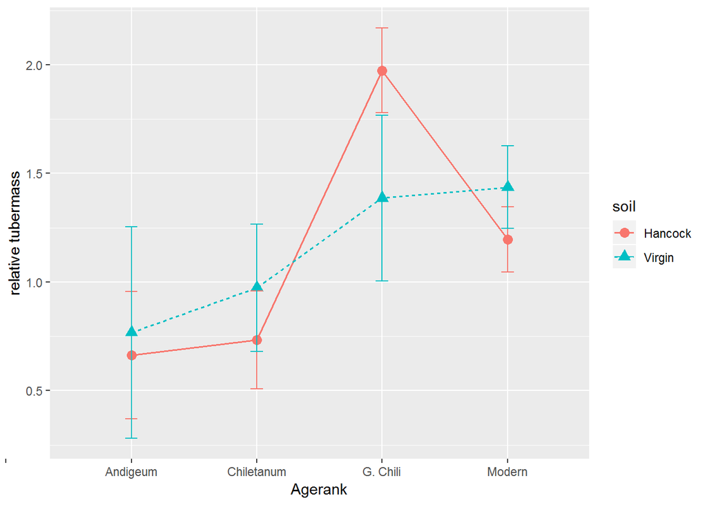

```r
rel_avg$agerank2 = as.factor(rel_avg$agerank2)
ggplot(rel_avg_high)+
  aes(x = agerank2, y = mean, color = soil)+
  scale_x_discrete(name = "Agerank", limits = c(" ", "Andigeum","Chiletanum", "G. Chili", "Modern"))+
  scale_y_continuous(name =  "relative tubermass")+
  geom_line(aes(linetype=soil), size=.6)+
  geom_point(aes(shape=soil), size=3)+
  geom_errorbar(aes(ymax=mean+se, ymin=mean-se), width=.1)
```

So we see that more modern perform better in term of tubermass in high nutrient conditions. Also, see a additive microbial effect in that with more modern varieties we see a boast relative to sterile. However, with fertilizer we see that landraces perform more poorly that sterile.

```
## geom_path: Each group consists of only one observation. Do you need to
## adjust the group aesthetic?
```

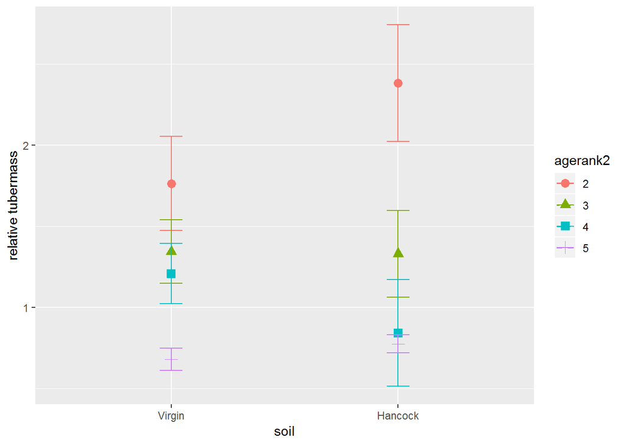

```r
rel_avg_low$agerank2 = as.factor(rel_avg_low$agerank2)
ggplot(rel_avg_low)+
  aes(x = soil, y = mean, color = agerank2)+
  scale_x_discrete(name = "soil", limits = c("Virgin", "Hancock"))+
  scale_y_continuous(name = "relative tubermass")+
  geom_line(aes(linetype=agerank2), size=.6)+
  geom_point(aes(shape=agerank2), size=3)+
  geom_errorbar(aes(ymax=mean+se, ymin=mean-se), width=.1)
```

Interestingly there’s no soil interaction effect. Or at least it isn’t strong enought to see any differences in low nutrient conditions. We can maybe say that Andigenum (agerank 2) did alot better in hancock than in Virgin. This is due to a soil effect?

# Hypothesis: Elite Varieties will be less dependent on soil microbial communities. Especially in low nutrient condtions.

We are now trying to measure plant response to microbes.

```r
new_data <- subset(new_meta_data2, agerank2 != "1" & soil != "Sterile")
new_data <- subset(new_data, Nutrient == "Low")

rel_tuber <- lmer(rel_biomass2 ~ agerank2*soil + (1|Clade:variety2), data = new_data)
summary(rel_tuber)
```

```
## Linear mixed model fit by REML. t-tests use Satterthwaite's method [
## lmerModLmerTest]
## Formula: rel_biomass2 ~ agerank2 * soil + (1 | Clade:variety2)
##    Data: new_data
##
## REML criterion at convergence: 275.3
##
## Scaled residuals:
##     Min      1Q  Median      3Q     Max
## -1.8856 -0.3973  0.0065  0.4147  3.7994
##
## Random effects:
##  Groups         Name        Variance Std.Dev.
##  Clade:variety2 (Intercept) 0.009794 0.09896
##  Residual                   0.911972 0.95497
## Number of obs: 98, groups:  Clade:variety2, 14
##
## Fixed effects:
##                     Estimate Std. Error      df t value Pr(>|t|)
## (Intercept)           3.2235     0.4159 43.8511   7.751 9.41e-10 ***
## agerank2             -0.5207     0.1185 44.1887  -4.394 6.89e-05 ***
## soilVirgin           -0.7668     0.5527 84.7399  -1.387    0.169
## agerank2:soilVirgin   0.1679     0.1579 84.7539   1.063    0.291
## ---
## Signif. codes:  0 '***' 0.001 '**' 0.01 '*' 0.05 '.' 0.1 ' ' 1
##
## Correlation of Fixed Effects:
##             (Intr) agrnk2 slVrgn
## agerank2    -0.937
## soilVirgin  -0.727  0.682
## agrnk2:slVr  0.680 -0.726 -0.937
```

```r
anova(rel_tuber)
```

|  | Sum Sq | Mean Sq | NumDF | DenDF | F value | Pr(>F) |
| --- | --- | --- | --- | --- | --- | --- |
| agerank2 | 25.958244 | 25.958244 | 1 | 12.40908 | 28.463869 | 0.0001586563 |
| soil | 1.755370 | 1.755370 | 1 | 84.73991 | 1.924808 | 0.1689655848 |
| agerank2:soil | 1.030797 | 1.030797 | 1 | 84.75385 | 1.130295 | 0.2907323267 |

Genotype was the only thing that mattered in determining variance in relative tuber yield…

## Plot of tuber yield in low nutrient conditions.

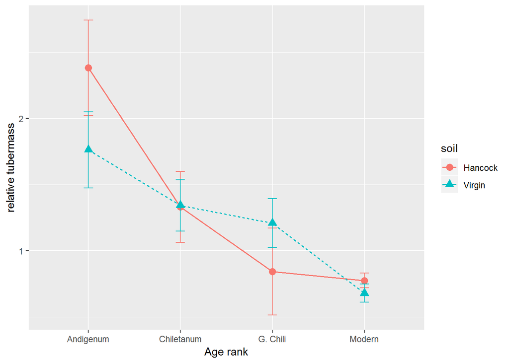

```r
rel_avg_low$agerank2 = as.integer(rel_avg_low$agerank2)
ggplot(rel_avg_low)+
  aes(x = agerank2, y = mean, color = soil)+
  scale_x_discrete(name = "Age rank", limits = c( "Andigenum","Chiletanum", "G. Chili", "Modern"))+
  scale_y_continuous(name = "relative tubermass")+
  geom_line(aes(linetype=soil), size=.6)+
  geom_point(aes(shape=soil), size=3)+
  geom_errorbar(aes(ymax=mean+se, ymin=mean-se), width=.1)
```

Looks like over all in low nutrient conditions, tuber yield was greater in more ancestral lines than more recent. Doesn’t matter the soil inoculum but we see that in both hancock and virgin more ancestral lines perform better. Overall, see relative tuber yield making a positive difference in low nutrient conditions in live soil. This isn’t the case with more modern potato varieties because see that they actually perform more poorly than in sterile conditions. In contrast in high fertilizer conditions we see the exact opposite effect where modern varieties regardless of soil see a additional additive fertilizer + microbial treatment effect. This is pretty interesting.